# Nice plots with R

**Example:** Boxplot of NUSAP1 expression levels according to tumour grade and Kruskal-Wallis test p-value:

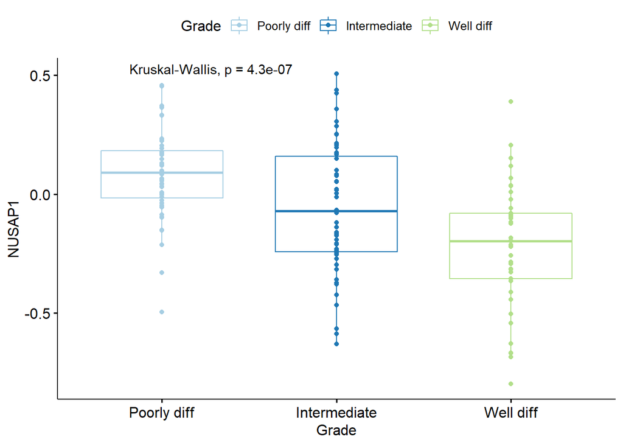

```r
p<-ggboxplot(data, x = "Grade", y = "NUSAP1",
               color = "Grade", palette = "Paired",
               add = "point")

p + stat_compare_means()      # Adds global p-value, default Kruskal-wallis test
```

You can adjust the position of the label with options `label.x` and `label.y`. In this example we only adjunts the vertical position of the label:

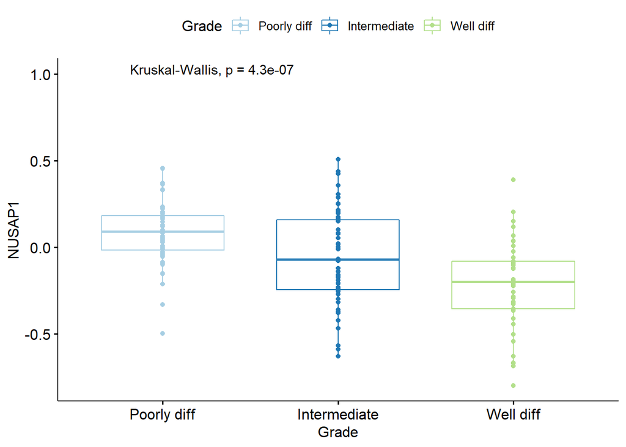

```r
p + stat_compare_means(label.y = 1)      # label.y = 1 adjusts the vertical position of the label
```

You can implement an ANOVA instead of the default Kruskal-Wallis test with option `method`:

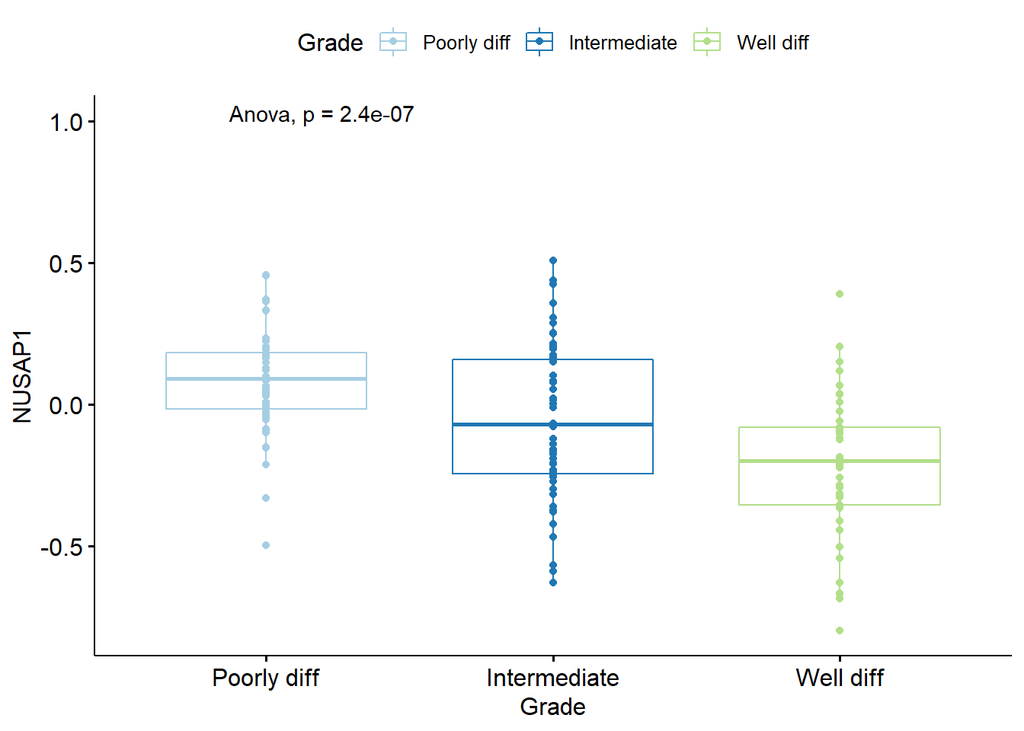

```r
p + stat_compare_means(method="anova",label.y = 1)
```

You can also add pairwise tests by specifying a list of the different pairs to be compared:

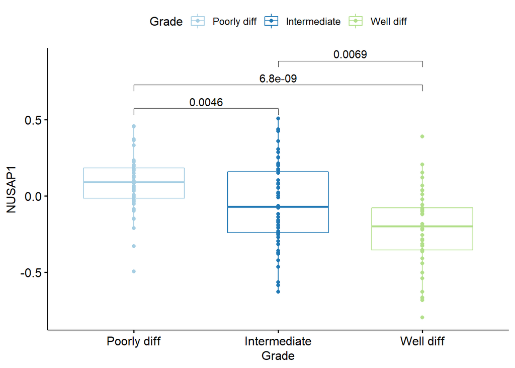

```r
my_pairs <- list( c("Poorly diff", "Intermediate"), c("Poorly diff", "Well diff"), c("Intermediate", "Well diff") )

p + stat_compare_means(comparisons = my_pairs) # Adds pairwise tests p-values
```

You can display both, the global p-value and the pairwise comparisons:

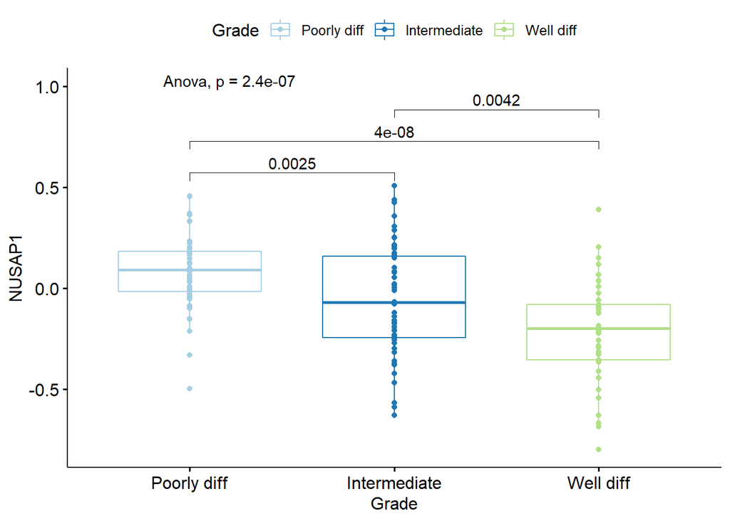

```r
p + stat_compare_means(method="t.test",comparisons = my_pairs)+         # pairwise p-values
  stat_compare_means(method="anova",label.y = 1)                        # global p-value
```

# 6 Empirical cumulative distribution fuction

For a value x, the empirical cumulative distribution function of a numerical variable provides the proportion of observations with a value lower or equal to x.

## 6.1 Base R ecdf

`ecdf()`: Base R function to obtain the empirical cumulative distribution function of a numerical variable.

**Example:** Empirical cumulative distribution function of NUSAP1 levels:

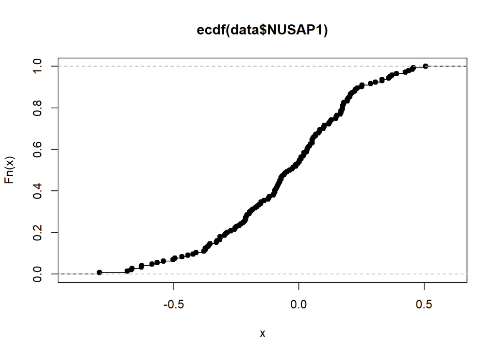

```r
f<-ecdf(data$NUSAP1)
plot(f)
```

## 6.2 Ecdf plots with ggpubr

`ggecdf()`: ggpubr function to obtain the empirical cumulative distribution function of a numerical variable.

**Example:** Empirical cumulative distribution function of NUSAP1 levels according to Grade:

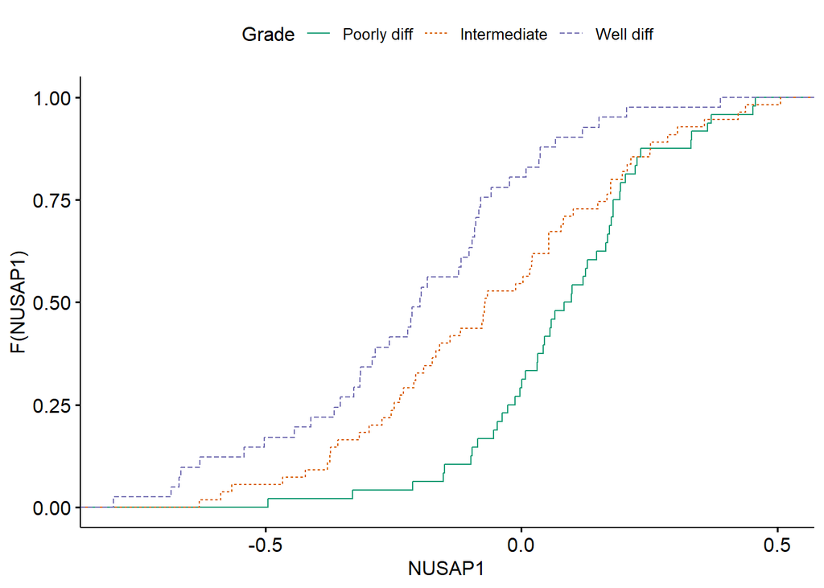

```r
ggecdf(data, x = "NUSAP1",
         color = "Grade",
         linetype = "Grade",
         palette = "Dark2")
```

# 7 Scatter plots

Scatter plots provide a graphical representation of the possible relationship between two numerical variables.

## 7.1 Base R scatter plots

`plot(x,y)`: Base R function to obtain the scatter plot between `x` and `y`.

`abline()`: Adds a straight line to the current plot

**Example:** Scatter plot of NUSAP1 and DIAPH3 expression levels:

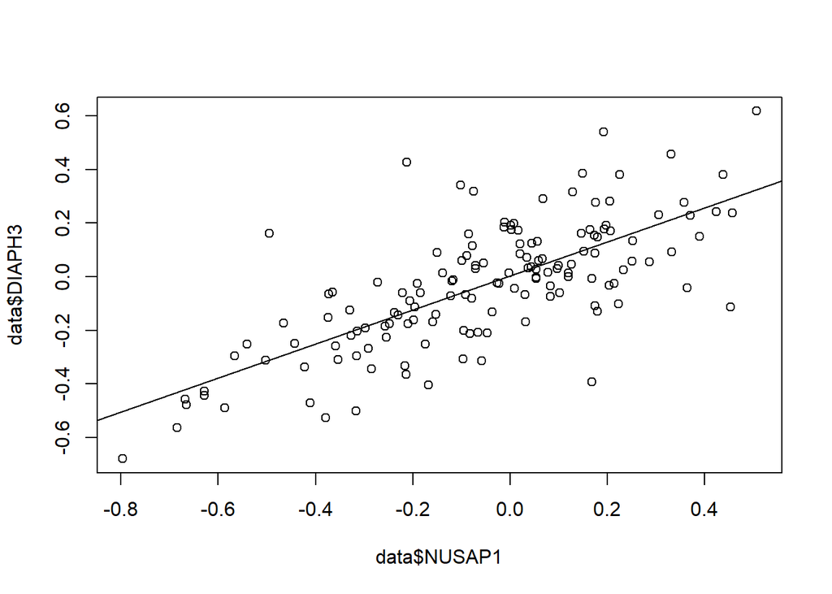

```r
plot(data$NUSAP1, data$DIAPH3)
abline(lm(data$DIAPH3 ~ data$NUSAP1))
```

## 7.2 Scatter plots with ggpubr

`ggscatter()`: ggpubr function to obtain the scatter plot between two numerical variables.

**Example:** Scatter plot of NUSAP1 and DIAPH3 expression levels with regression line:

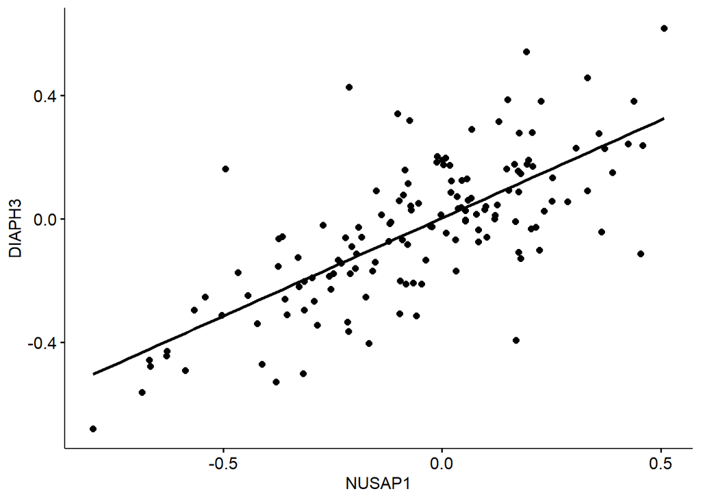

```r
ggscatter(data, x = "NUSAP1", y = "DIAPH3",
          add = "reg.line")
```

There are several options to improve the scatter plot. For instance, you can add confidence intervals, change the color of the line and the confidence band and display the correlation coefficient as follows:

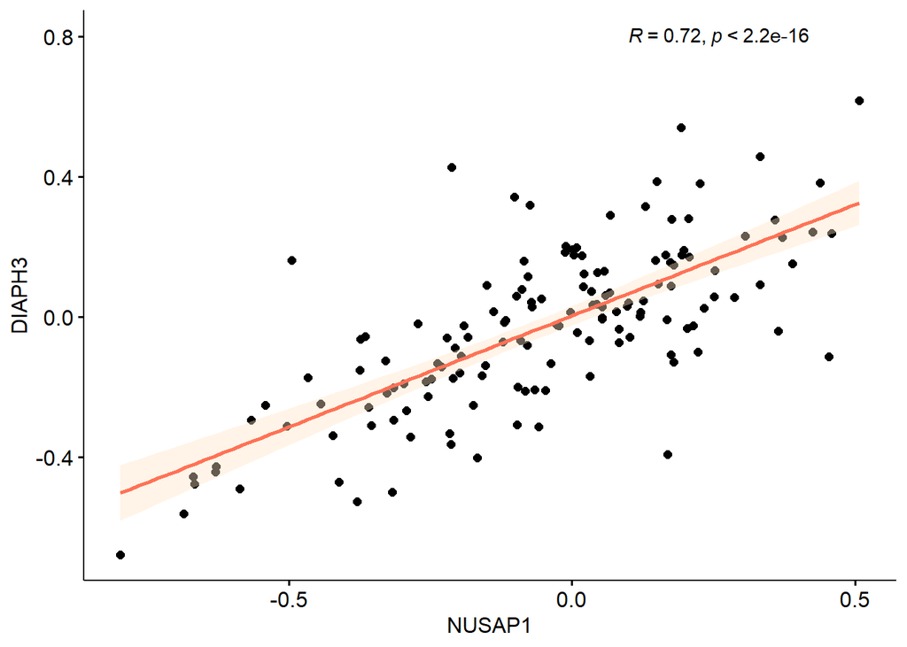

```r
ggscatter(data, x = "NUSAP1", y = "DIAPH3",
          add = "reg.line",                                      # regression line
          conf.int = TRUE,                                       # confidence interval
          add.params = list(color = "coral1", fill = "bisque")   # color
          )+
  stat_cor(method = "pearson", label.x = .1, label.y = 0.8)      # correlation coefficient
```

**Scatter plot according to a categorical variable**

**Example:** Scatter plot of NUSAP1 and DIAPH3 expression levels with regression lines for each Grade:

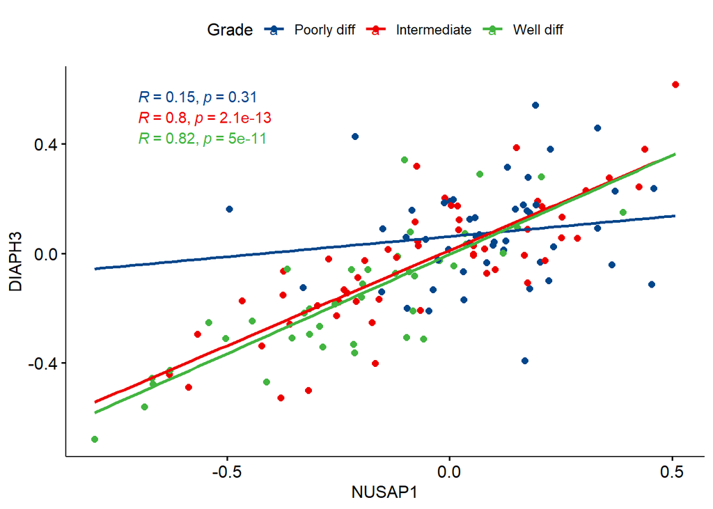

```r
ggscatter(data, x = "NUSAP1", y = "DIAPH3",
          add = "reg.line",                           # regression line
          color = "Grade", palette = "lancet",           # color by "Grade"
          fullrange = TRUE,                           # extending the regression line
          )+
  stat_cor(aes(color = Grade), label.x = -0.7)        # correlation coefficient
```

**Example:** Separate scatters plots of NUSAP1 and DIAPH3 expression levels with regression lines for each Grade:

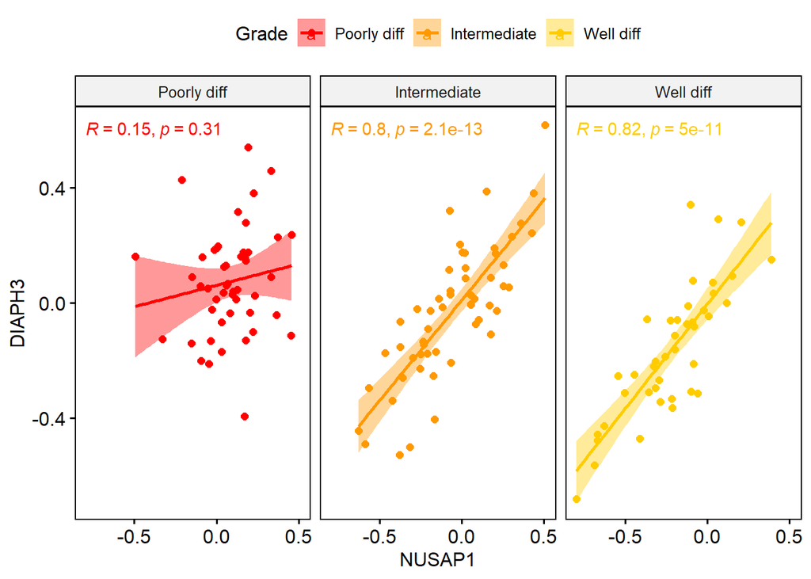

```r
ggscatter(data, x = "NUSAP1", y = "DIAPH3",
          add = "reg.line",                              # regression line
          color = "Grade", palette = "ucscgb",           # color by groups "Grade"
          facet.by = "Grade",
          conf.int = TRUE) +
  stat_cor(aes(color = Grade), label.y = .6)
```

**Scatter plot with ellipses**

**Example:** Scatter plot of NUSAP1 and DIAPH3 expression levels with ellipses for each Grade:

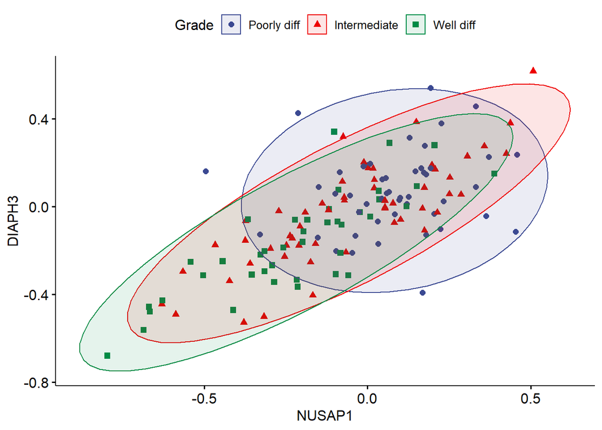

```r
ggscatter(data, x = "NUSAP1", y = "DIAPH3",
          color = "Grade", palette = "aaas",
          shape = "Grade",
          ellipse = TRUE)
```

# 8 Barplots

Barplots are mainly used for categorical variables. They represent either counts (the number of observations at each category) or proportions (relative frequency of observations at each category).

## 8.1 Base R Barplots

`barplot()`: R function to obtain a barplot from a frequency table.

**Example:** Table of counts (absolute frequencies) and barplot of Grade:

```r
table(data$Grade)  # counts: absolute frequencies
```

```
##
##  Poorly diff Intermediate    Well diff
##           48           55           41
```

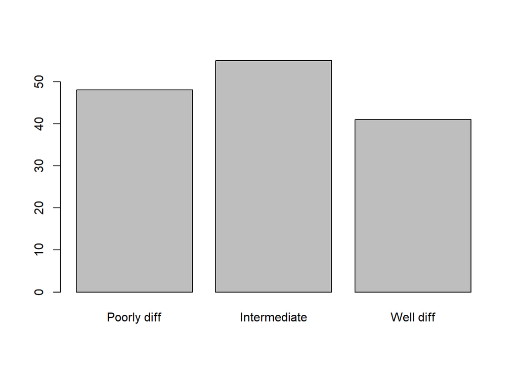

```r
barplot(table(data$Grade))  # barplot of counts
```

**Example:** Table of proportions (relative frequencies) and barplot of Grade variables:

```r
prop.table(table(data$Grade))  # proportions: relative frequencies
```

```
##
##  Poorly diff Intermediate    Well diff
##    0.3333333    0.3819444    0.2847222
```

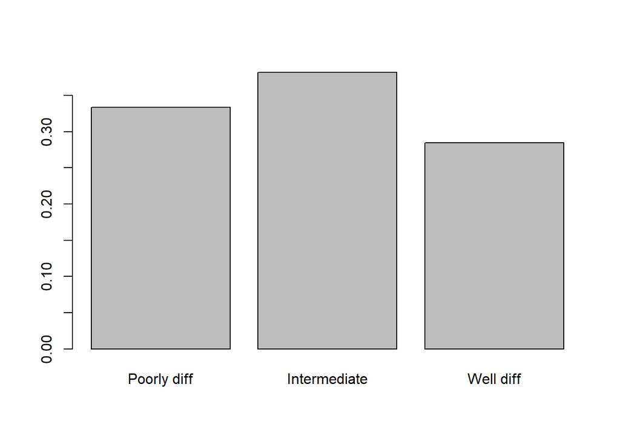

```r
barplot(prop.table(table(data$Grade)))  # barplot of proportions
```

The barplot can be improved by customizing several options as the x and y labels and the color the bars:

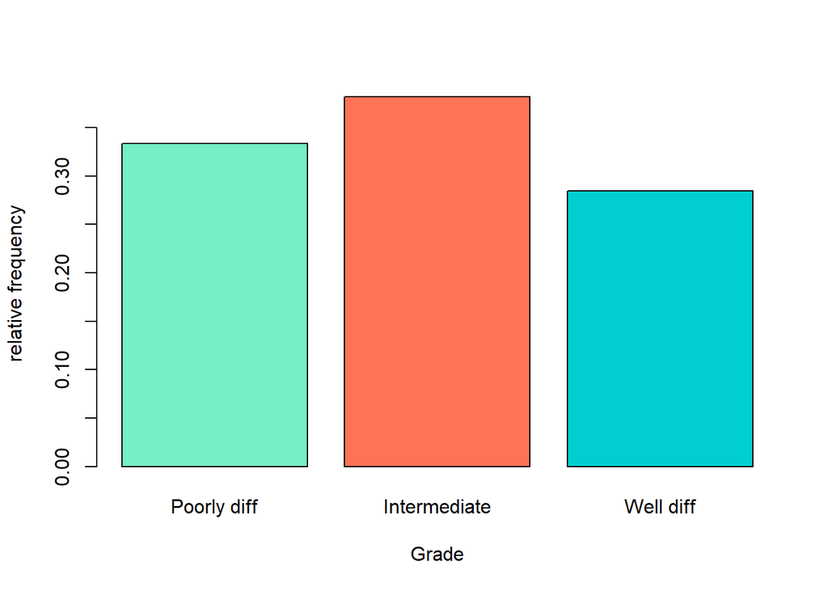

```r
relfreq<-prop.table(table(data$Grade))  # proportions: relative frequencies

barplot(relfreq, xlab="Grade", ylab="relative frequency",
        col=c("aquamarine2", "coral1","darkturquoise"))
```

## 8.2 Barplots with ggpubr

`ggbarplot()`: ggpubr function to obtain a barplot from a data frame. It requires the table of counts or proportions to be transformed into a data frame.

### 8.2.1 Barplots for one variable

**Example:** Table of counts (absolute frequencies) and barplot of Grade:

```r
freq<-table(data$Grade)  # counts: absolute frequencies
freq
```

```
##
##  Poorly diff Intermediate    Well diff
##           48           55           41
```

```r
freq<-as.data.frame(freq) # transform the table of counts into a data frame
freq
```

```
##           Var1 Freq
## 1  Poorly diff   48
## 2 Intermediate   55
## 3    Well diff   41
```

```r
colnames(freq)<-c("Grade","Freq")   # Rename the columns of the data frame
freq
```

```
##          Grade Freq
## 1  Poorly diff   48
## 2 Intermediate   55
## 3    Well diff   41
```

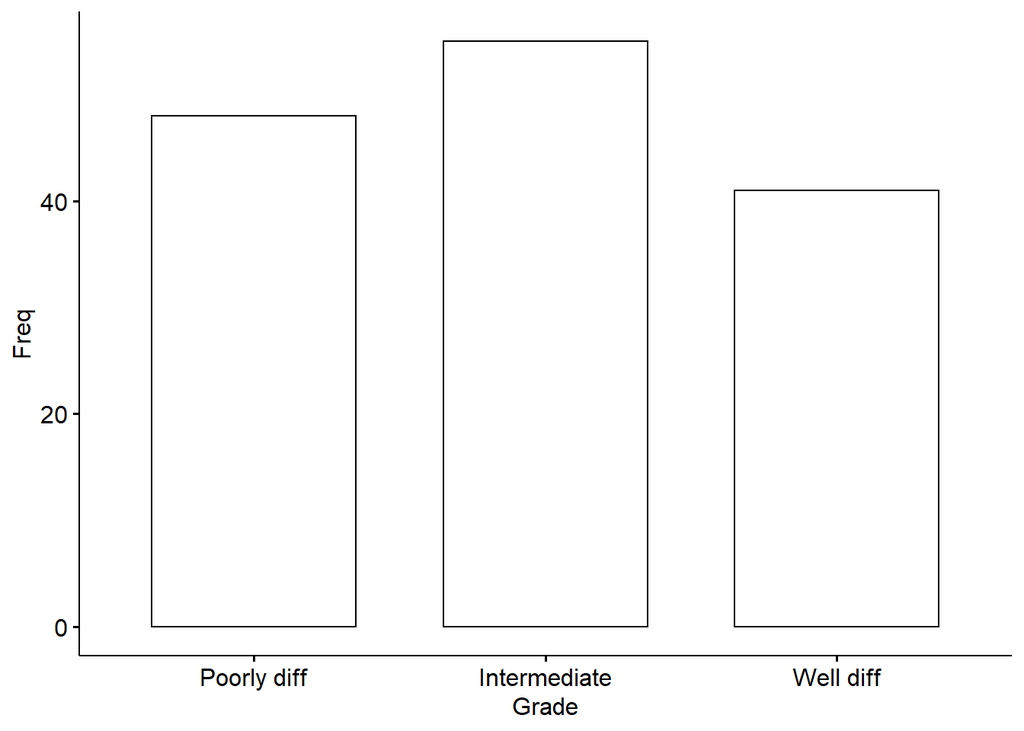

```r
ggbarplot(freq, x="Grade", y="Freq")  # barplot of counts
```

The plot can be customized with colored bars and labels (counts):

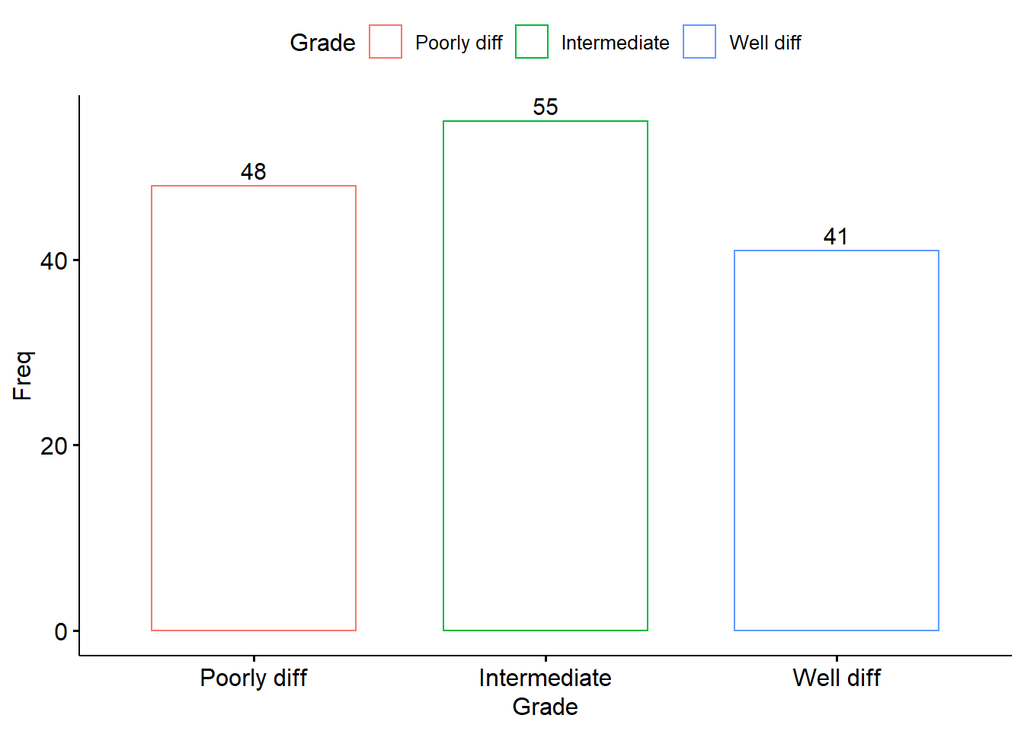

```r
ggbarplot(freq, x="Grade", y="Freq",
          color = "Grade",
          label = TRUE)             # show labels (counts for each category)
```

Additional options are shown in this example:

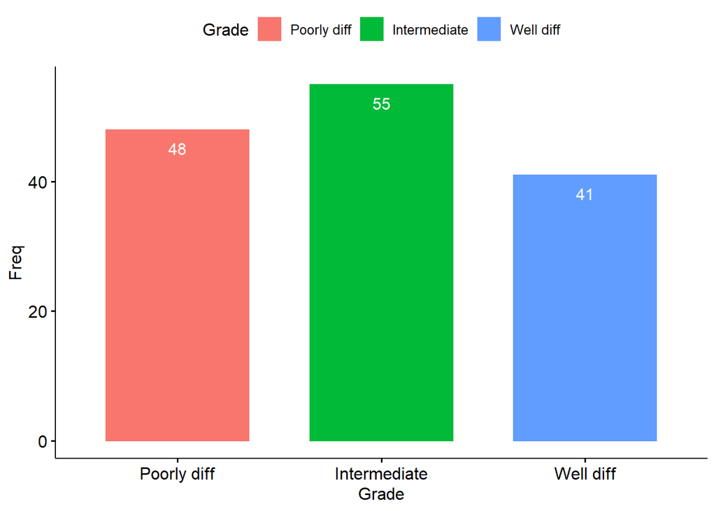

```r
ggbarplot(freq, x="Grade", y="Freq",
          color = "Grade", fill ="Grade",   # fill the bars
          label = TRUE,             # show labels (counts for each category)
          lab.pos = "in",  lab.col = "white")            # puts the labels in white inside the bars
```

### 8.2.2 Barplot of counts for two variables

**Example:** Table of counts (absolute frequencies) and barplot of Grade and event variables:

```r
freq<-table(data$Grade, data$event)  # 2 by 2 table of counts: rows = Grade, columns = event
freq
```

```
##
##                no yes
##   Poorly diff  26  22
##   Intermediate 36  19
##   Well diff    34   7
```

```r
freq<-as.data.frame(freq)                     # transform the table into a data frame
colnames(freq)<-c("Grade","event","Freq")     # rename the columns of the data frame
freq
```

```
##          Grade event Freq
## 1  Poorly diff    no   26
## 2 Intermediate    no   36
## 3    Well diff    no   34
## 4  Poorly diff   yes   22
## 5 Intermediate   yes   19
## 6    Well diff   yes    7
```

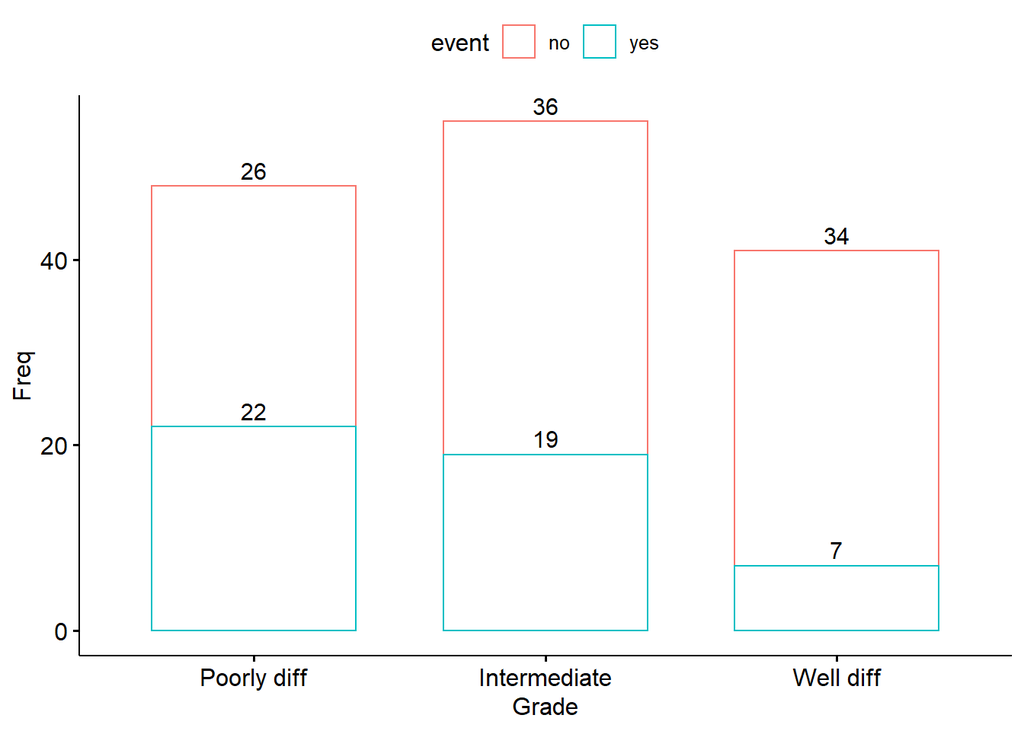

```r
ggbarplot(freq, x="Grade", y="Freq",
          color = "event",
          label = TRUE)
```

### 8.2.3 Barplots of row proportions for two variables

The table of row proportions is obtained by adding `,1` to `prop.table()`. The sums of the proportions by rows are equal to 1.

The barplot is obtained by specifying `x` as the variable that defines de rows of the table and the other variable defines the `color` of the plot. You should check that the heights of the bars of the barplot are equal to 1.

**Example:** Table of row proportions and barplot of Grade and event variables:

```r
freqbyrow<-prop.table(table(data$Grade, data$event),1) #  row proportions (Grade)
freqbyrow
```

```
##
##                       no       yes
##   Poorly diff  0.5416667 0.4583333
##   Intermediate 0.6545455 0.3454545
##   Well diff    0.8292683 0.1707317
```

```r
freqbyrow<-as.data.frame(freqbyrow)                  # transform the table into a data frame
colnames(freqbyrow)<-c("Grade","event","Freq")
freqbyrow
```

```
##          Grade event      Freq
## 1  Poorly diff    no 0.5416667
## 2 Intermediate    no 0.6545455
## 3    Well diff    no 0.8292683
## 4  Poorly diff   yes 0.4583333
## 5 Intermediate   yes 0.3454545
## 6    Well diff   yes 0.1707317
```

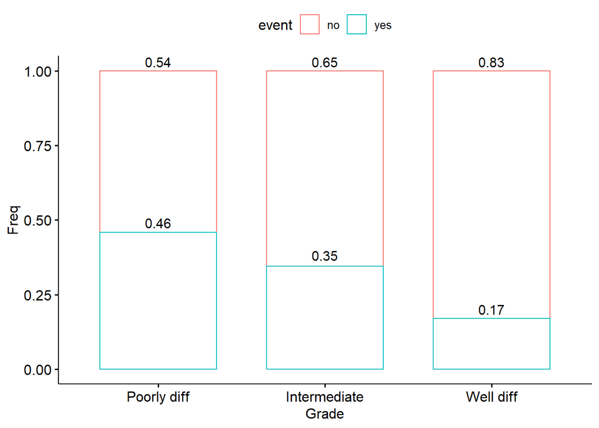

```r
ggbarplot(freqbyrow, x="Grade", y="Freq",       # x = variable that defines the rows of the table
          color = "event",
          label = TRUE,
          lab.nb.digits = 2)                    # number of digits for the proportions
```

### 8.2.4 Barplots of column proportions for two variables

The table of column proportions is obtained by adding `,2` to `prop.table()`. The sums of the proportions by columns are equal to 1.

The barplot is obtained by specifying `x` as the variable that defines de columns of the table and the other variable defines the `color` of the plot. You should check that the heights of the bars of the barplot are equal to 1.

**Example:** Table of column proportions and barplot of Grade and event variables:

```r
freqbycol<-prop.table(table(data$Grade, data$event),2) # column proportions (event)
freqbycol
```

```
##
##                       no       yes
##   Poorly diff  0.2708333 0.4583333
##   Intermediate 0.3750000 0.3958333
##   Well diff    0.3541667 0.1458333
```

```r
freqbycol<-as.data.frame(freqbycol)
colnames(freqbycol)<-c("Grade","event","Freq")
freqbycol
```

```
##          Grade event      Freq
## 1  Poorly diff    no 0.2708333
## 2 Intermediate    no 0.3750000
## 3    Well diff    no 0.3541667
## 4  Poorly diff   yes 0.4583333
## 5 Intermediate   yes 0.3958333
## 6    Well diff   yes 0.1458333
```

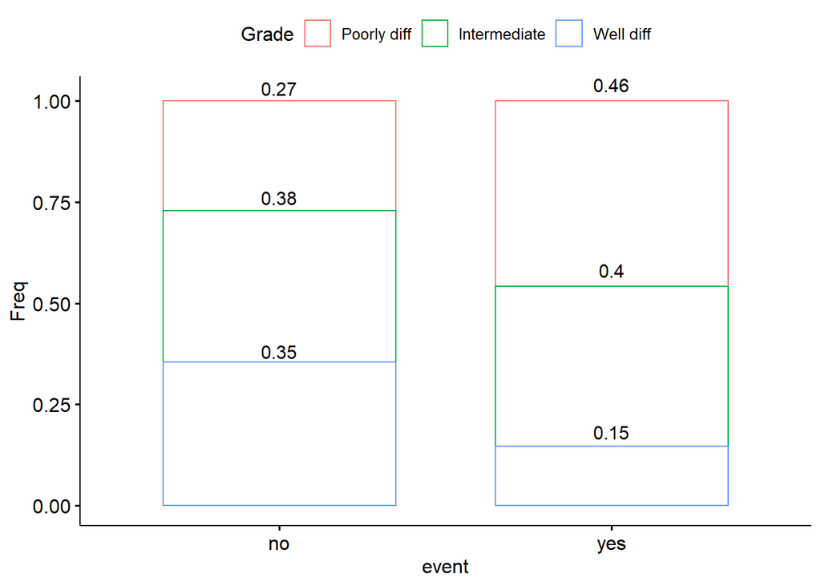

```r
ggbarplot(freqbycol, x="event", y="Freq",   # x = variable that defines the columns of the table
          color = "Grade",
          label = TRUE,
          lab.nb.digits = 2)                # number of digits for the proportions
```

# 9 Plots for paired and longitudinal data

So far we have considered one observation per subject, but some analysis involve multiple measures per subject. These data are called **paired data** when there are two observations per subject, **longitudinal data** when the observations for each individual were taken at different points in time or, in general, **repeated measures data**.

The code that we will use requires the data to be in long format:

**Wide format:** the repeated measures of a subject are in the same row, each measure in a different column

**Long format:** each reapeated measure of a subject is in a different row, each subject has as many rows as multiple measurements

At the end of this document there is an example on how to convert a data frame from wide to long format using function `pivot_longer()` from package **tidyr**

## 9.1 Plots for paired data with ggpubr

**Example:** We generate a data frame with paired data: the body temperature was measured before and after the administration of an antipyretic drug for 9 inviduals

```r
temp<-c(38, 36.7, 37.5, 38.1, 39.1, 37.1, 40, 39.2, 37.8, 38.3, 38.6, 36, 37.3, 36.4, 39.5, 37.5, 38.6, 39.1)
id<-as.factor(c(1,1,2,2,3,3,4,4,5,5,6,6,7,7,8,8,9,9))
time<-rep(c("before","after"),9)
data<-data.frame(id,time, temp)
```

Long format data frame:

```r
head(data)
```

```
##   id   time temp
## 1  1 before 38.0
## 2  1  after 36.7
## 3  2 before 37.5
## 4  2  after 38.1
## 5  3 before 39.1
## 6  3  after 37.1
```

`ggline()`: ggpubr function to plot lines between repeated measures for the same subject:

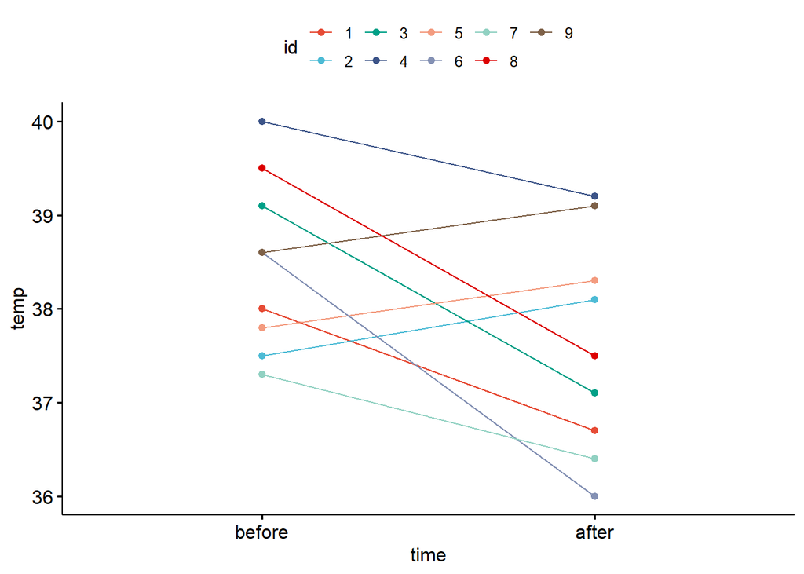

```r
ggline(data, x = "time", y = "temp",
       color = "id", palette = "npg")
```

`ggpaired()`: this ggpubr function provides an alternative plot for paired data:

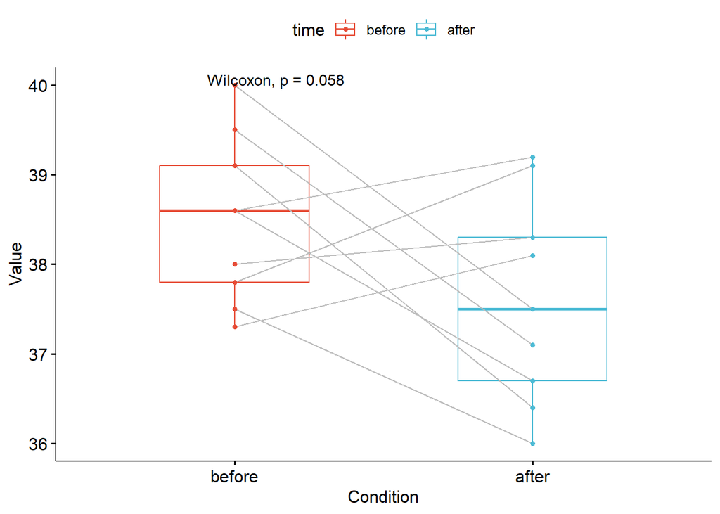

```r
ggpaired(data, x = "time", y = "temp",
   color = "time", line.color = "gray", line.size = 0.4,
   palette = "npg")+
 stat_compare_means(paired = TRUE)
```

## 9.2 Plots for longitudinal data with ggpubr

**Example:** We generate a data frame with longitudinal data: the water ph was measured from January to April in 3 locations of a river. Note that not all locations (subjects) have the same number of measurements in all time points:

```r
ph<-c(6.4, 6.5, 6.4, 6.8, 6.7, 6.6, 6.5, 6.2, 6.1, 6.6,
      6.7, 6.5, 6.2, 6.2, 6.3, 7.4, 6.8, 6.7,
      6.1, 6.8, 6.9, 7.9, 7.7, 7.6, 7, 7.3, 7.1,
       7.4, 7.2, 6.9, 8.1, 8.2, 8,7.8, 7.4, 8)

location<-c("A","A","A","B","B","B","C","C","C","C",
            "A","A","A","A","A","C","C","C",
            "A","A","A","B","B","B","C","C","C",
            "A","A","A","B","B","B","C","C","C")

month<-c(rep("Jan",10),rep("Feb",8),rep("Mar",9),rep("Apr",9))

data<-data.frame(ph, month,location)
```

Long format data:

```r
head(data)
```

```
##    ph month location
## 1 6.4   Jan        A
## 2 6.5   Jan        A
## 3 6.4   Jan        A
## 4 6.8   Jan        B
## 5 6.7   Jan        B
## 6 6.6   Jan        B
```

`ggline()`: ggpubr function to plot lines between repeated measures for the same subject.

Option `add="mean_se"` provides the mean and the standard error of the different measures for each location at each time point:

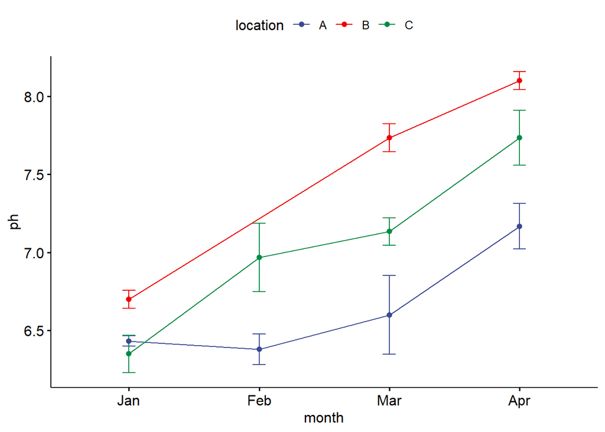

```r
ggline(data, x = "month", y = "ph",
       color = "location",
       add="mean_se",
       palette = "aaas")
```

## 9.3 Transform a wide data set to a long format

We will use function `pivot_longer()` from package **tidyr** to convert data from wide to long format.

**Example:** We generate a data frame with paired data: the body temperature was measured before and after the administration of an antipyretic drug for 9 inviduals

```r
temp_before<-c(38, 37.5, 39.1, 40, 37.8, 38.6, 37.3, 39.5, 38.6)
temp_after<-c(36.7, 38.1, 37.1, 39.2, 38.3, 36, 36.4, 37.5, 39.1)
id<-as.factor(1:9)

datawide<-data.frame(id,temp_before,temp_after)
```

Wide format data frame:

```r
datawide
```

```
##   id temp_before temp_after
## 1  1        38.0       36.7
## 2  2        37.5       38.1
## 3  3        39.1       37.1
## 4  4        40.0       39.2
## 5  5        37.8       38.3
## 6  6        38.6       36.0
## 7  7        37.3       36.4
## 8  8        39.5       37.5
## 9  9        38.6       39.1
```

`pivot_longer()`: tidyr function to transform a wide data set to a long format

```r
data<-pivot_longer(datawide, cols=(2:3))
data
```

```
## # A tibble: 18 x 3
##    id    name        value
##    <fct> <chr>       <dbl>
##  1 1     temp_before  38
##  2 1     temp_after   36.7
##  3 2     temp_before  37.5
##  4 2     temp_after   38.1
##  5 3     temp_before  39.1
##  6 3     temp_after   37.1
##  7 4     temp_before  40
##  8 4     temp_after   39.2
##  9 5     temp_before  37.8
## 10 5     temp_after   38.3
## 11 6     temp_before  38.6
## 12 6     temp_after   36
## 13 7     temp_before  37.3
## 14 7     temp_after   36.4
## 15 8     temp_before  39.5
## 16 8     temp_after   37.5
## 17 9     temp_before  38.6
## 18 9     temp_after   39.1
```

```r
colnames(data)<-c("id","time","temp")
```

Long format data frame:

```r
data
```

```
## # A tibble: 18 x 3
##    id    time         temp
##    <fct> <chr>       <dbl>
##  1 1     temp_before  38
##  2 1     temp_after   36.7
##  3 2     temp_before  37.5
##  4 2     temp_after   38.1
##  5 3     temp_before  39.1
##  6 3     temp_after   37.1
##  7 4     temp_before  40
##  8 4     temp_after   39.2
##  9 5     temp_before  37.8
## 10 5     temp_after   38.3
## 11 6     temp_before  38.6
## 12 6     temp_after   36
## 13 7     temp_before  37.3
## 14 7     temp_after   36.4
## 15 8     temp_before  39.5
## 16 8     temp_after   37.5
## 17 9     temp_before  38.6
## 18 9     temp_after   39.1
```